# 1 General Theory of Statistical Tests

Hypothesis testing is a fundamental concept in the scientific world. The purpose of hypothesis testing is to present a decision rule, established before using sample results, that allows a choice to be made between two statistical hypotheses.

## 1.1 Key concepts

What is a statistical hypothesis? It is an *a priori* statement about one or more characteristics of a population, such as the value of parameters or the distribution of observations.

There are two types of hypotheses:

- **Null hypothesis (H₀)**: The hypothesis submitted to statistical testing and considered true for the test, $H_0$, is often a simple model or a defined value of a parameter. For example, there is no difference between the means of two groups. $H_0$ : $\mu_1 = \mu_2$
- **Alternative hypothesis (H₁)**: hypothesis different from $H_0$, commonly its opposite. Example $H_1$: $\mu_1 ≠ \mu_2$

What is type-I and type-II errors ?

- **α Type I error (false positive)**: It is the probability to reject $H_0$ when $H_0$ is **true**. In other words, it’s the risk of incorrectly concluding, based on the results obtained, that there is a real difference when in fact it is due to chance. Example: a player plays roulette, spins the wheel 6 times, and sees 4 red numbers and 2 black numbers come up. He concludes that there are twice as many red numbers as black numbers.

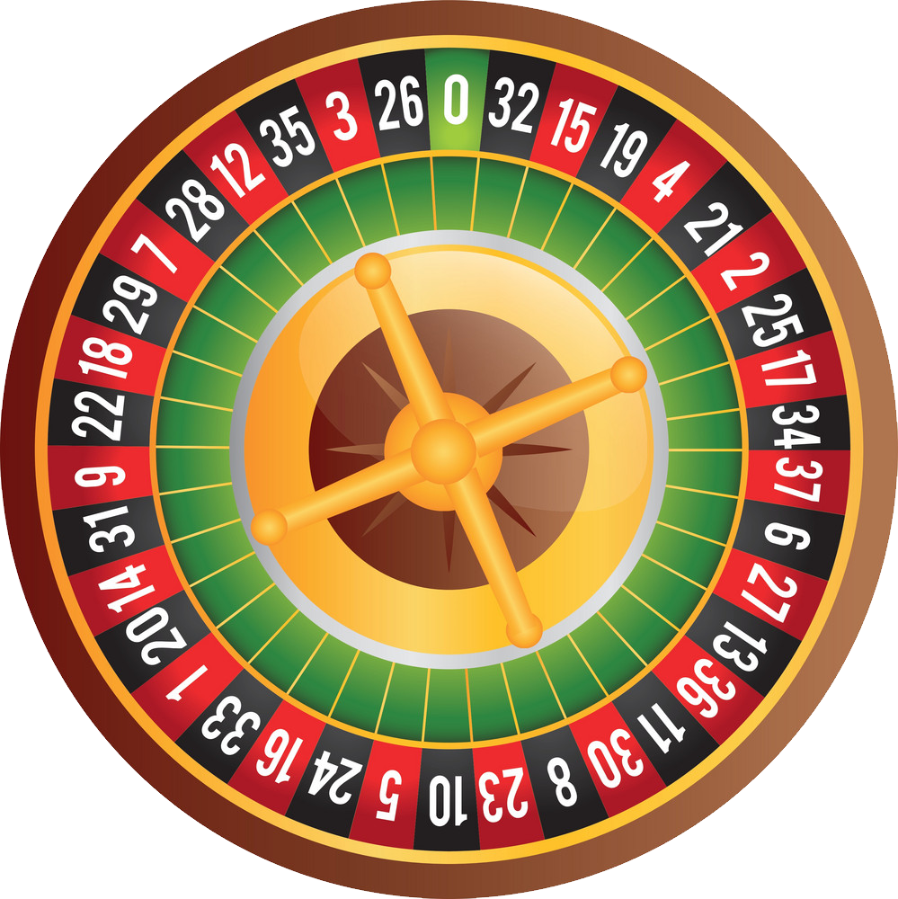

Figure 1: example of the roulette game

- **β Type II error (false negative)**: It’s the probability of **not** rejecting $H_0$ when $H_0$ is false. In other words, it is the risk of wrongly concluding that there is no difference when there is actually a difference.

Statistical power, it is the probability to reject $H_0$ when $H_0$ is false. $Power = 1 - \beta$

Table 1: Hypothesis testing, types of error

| Your decision/Reality | **$H_0$ is true** | **$H_0$ is false** |
| --- | --- | --- |
| **Do not reject $H_0$** (test non-significant) | **Correct** decision | Wrong decision |
| **Reject $H_0$** (test significant) | Wrong decision | **Correct decision** |

## 1.2 Student’s test (ou t test)

The Student’s t-test allows for a simple but important comparison: that of the means between two groups. The test statistic is defined as

$$t = c \, \frac{\bar{m}_1 - \bar{m}_2}{s}$$

With $\bar{m}_1$ and $\bar{m}_2$ are the means of the values in the two groups, $c$ is a constant depending on the sample sizes, $s$ is pooled standard deviation.
$$\bar{m}_1 = \frac{1}{n_1} \sum_{i=1}^{n_1} x_{1,i}
\qquad
\bar{m}_2 = \frac{1}{n_2} \sum_{i=1}^{n_2} x_{2,i}$$

$s_1^2$ and $s_2^2$ are unbiased estimators of the intra-group variance.

$$s_1^2 = \frac{1}{n_1 - 1} \sum_{i=1}^{n_1} (x_{1,i} - \bar{m}_1)^2
\qquad
s_2^2 = \frac{1}{n_2 - 1} \sum_{i=1}^{n_2} (x_{2,i} - \bar{m}_2)^2$$

$$s =
\sqrt{
\frac{(n_1 - 1)s_1^2 + (n_2 - 1)s_2^2}
{n_1 + n_2 - 2}
}$$

$$c = \sqrt{\frac{n_1 n_2}{n_1 + n_2}}$$

### 1.2.1 Student two-sample test

Compare the means of two independent groups: trt2 ($n=10$) et crtl ($n=10$).

**Assumptions**:

The distributions of the two groups must be Normally distributed.

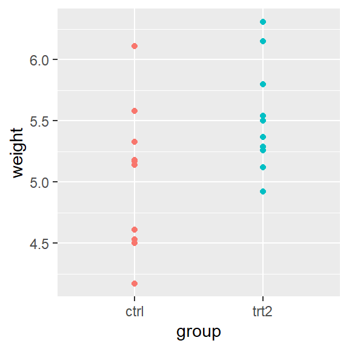

Figure 2: Data example of two groups.

```r
tt <- with(exemple_data,
          t.test(weight[group =="ctrl"],
                 weight[group =="trt2"],
                 var.equal = TRUE))
tt
```

```
    Two Sample t-test

data:  weight[group == "ctrl"] and weight[group == "trt2"]
t = -2.134, df = 18, p-value = 0.04685
alternative hypothesis: true difference in means is not equal to 0
95 percent confidence interval:
 -0.980338117 -0.007661883
sample estimates:
mean of x mean of y
    5.032     5.526
```

There is a difference between my two small sample groups. What would happen if we artificially increased the sample size by duplicating the data? I am keeping the same groups.

[figure not shown]

```
    Two Sample t-test

data:  weight[group == "ctrl"] and weight[group == "trt2"]
t = -7.0777, df = 198, p-value = 2.483e-11
alternative hypothesis: true difference in means is not equal to 0
95 percent confidence interval:
 -0.6316394 -0.3563606
sample estimates:
mean of x mean of y
    5.032     5.526
```

In this example, I duplicated the dataset 10 times. We can see that the means are **identical**, but the associated p-value is much **lower**:

- The statistical power associated with Student’s t-test depends on the sample size. The greater the number of observations, the more significant the results will be.

**Exercise** : Reproduce figure 3 using simulated data from a normal distribution: group 1 $\mathcal{N}(10,\,1)$ ; group 2 $\mathcal{N}(10.5,\,1)$. For each groups, the initial sample size is 20.

## 1.3 Wilcoxon test

### 1.3.1 Wilcoxon two-sample test

The Wilcoxon two-sample test is a nonparametric test because no particular assumption is made to the distribution of the data, and it can be perform in very small sample size. The main idea of this test is to ranks all of the data and calculates the sum of the ranks for one of the groups. The null hypothesis $H_0$ is that the **two groups have identical distribution**.

⚠️

**One not correct thing** about this test is it can be describe as a test for the median. This test can be use as a median test **only** if the distribution in the two groups is known to have the **same shape**.

⚠️

**Test Statistic** We will use $SR$, the sum of the ranks of the group with the smallest sample size. $n_{\min}$ is the minimum between group1 and group2 (and $n_{\max}$ is the maximum between group1 and group2).

- **When $n_{\min} < 10$:**

$C = SR - \frac{n_{\min}(n_{\min} + 1)}{2} \sim_{H_0} \text{centered Wilcoxon}(n_{\min}, n_{\max})$

- **When $n_{\min} > 10$:**

$SR$ is approximately Normally distributed:

$SR \sim_{H_0} \mathcal{N}\!\left(\frac{n_{\min}(n_{\min} + n_{\max} + 1)}{2} \; ; \; \sqrt{\frac{n_{\max}}{6}\left(\frac{n_{\min}(n_{\min} + n_{\max} + 1)}{2}\right)}\right)$

The test statistic **$U$** is:

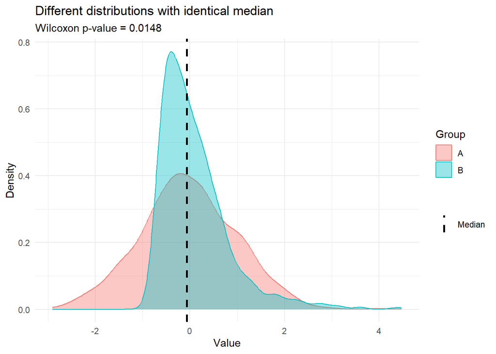

Figure 4: Plot of two distributions with identical median.

## 1.4 Fisher’s Exact Test

Fisher’s exact test is a non-parametric statistical test used to assess the independence between two binary variables in a $2×2$ contingency table. It is most commonly applied when the assumptions underlying $\chi^2$ test and Yates’s $\chi^2$ test are not valid.

⚠️

This test assumes that the data are independent of each other, so care must be taken with statistical individuals (e.g., in single-cell data coming from the same patient).

⚠️

Table 3: Contingency table

|  | **Smoke** | **Don’t smoke** | *Total* |
| --- | --- | --- | --- |
| **$ < 40 yo$** | $a$ | $b$ | $n1$ |
| **$ >40 yo$** | $c$ | $d$ | $n2$ |
| *Total* | $m1$ | $m2$ | $N$ |

$H_0$: The two variables are independent

$p_{abcd}$ is the probability that $Y=a$ with n1, m1 and N known, fixed.

$p_{abcd} = \mathbb{P}\!\left( Y = a \mid n1,\; m1,\; N \right)$

$Y \sim Hypergeometric(m1, N-m1, N)$

So $p_{abcd} = \dfrac{(a + b)! * (c + d)! *(a + c)! *(b + d)!}{a!* \, b!* \, c!* \, d!* \, n!}$

To help to understand this probability, we will use numerical examples.

```r
tab <- matrix(
  c(5, 8,
    3, 15),
  nrow = 2,
  byrow = TRUE
)

colnames(tab) <- c("Smoke", "Dont_Smoke")
rownames(tab) <- c("less_than_49", "more_than_49")

print(tab)
```

```
             Smoke Dont_Smoke
less_than_49     5          8
more_than_49     3         15
```

```r
fisher.test(tab)
```

```
    Fisher's Exact Test for Count Data

data:  tab
p-value = 0.2285
alternative hypothesis: true odds ratio is not equal to 1
95 percent confidence interval:
  0.4483044 24.6647356
sample estimates:
odds ratio
  3.005488
```

```r
## Manual computation of Fisher's exact test p-value

# Parameters fixed by the margins of the contingency table
# N  : total number of observations
# m1 : total number of Smokers
# n1 : total number of observations in less than 40yo

N  <- sum(tab)
m1 <- sum(tab[, 1])
n1 <- sum(tab[1, ])

## 1. Possible values of the random variable A

# A = number of smokers in Group < 40yo
# Under H0 (independence) and conditional on the margins,
# A follows a hypergeometric distribution.
#
# The admissible values of A are constrained by the margins:
#   0 <= A <= min(n1, m1)
# Here: 0 <= A <= 8

a_vals <- 0:m1


## 2. Hypergeometric probabilities

# For each possible value of A, compute the probability with dhyper():
probs <- dhyper(a_vals, m1, N - m1, n1)

## 3. Reconstruct all compatible 2x2 tables
# Each value of A uniquely determines a 2x2 table with the same margins:
# This allows us to explicitly list all possible tables considered
# in Fisher's exact test

fisher_table <- data.frame(
  a = a_vals,
  b = n1 - a_vals,
  c = m1 - a_vals,
  d = N - n1 - (m1 - a_vals),
  Probability = probs
)
print(fisher_table)
```

```
  a  b c  d  Probability
1 0 13 8 10 0.0055469040
2 1 12 7 11 0.0524434557
3 2 11 6 12 0.1835520949
4 3 10 5 13 0.3106266222
5 4  9 4 14 0.2773451984
6 5  8 3 15 0.1331256952
7 6  7 2 16 0.0332814238
8 7  6 1 17 0.0039154616
9 8  5 0 18 0.0001631442
```

```r
## 4. Probability of the observed table
# In the observed data:
# a_obs = 5
a_obs <- tab[1, 1]

p_obs <- dhyper(a_obs, m1, N - m1, n1)

## 5. Identify "as or more extreme" tables
# For the two-sided Fisher test,
# a table is considered at least as extreme as the observed one
# if its hypergeometric probability is less than or equal to
# the probability of the observed table.
fisher_table$Extreme <- fisher_table$Probability <= p_obs

## 6. Computation of the p-value
# The p-value is obtained by summing the probabilities
# of all tables classified as "extreme".
p_value_manual <- sum(fisher_table$Probability[fisher_table$Extreme])

test.pval <- fisher.test(tab)$p.value
print(paste0("Manual pvalue = ", p_value_manual,
             "Test pvalue = ", test.pval))
```

```
[1] "Manual pvalue = 0.228476084538376Test pvalue = 0.228476084538376"
```

# 2 Multiple testing

## 2.1 P-hACKing, P-hARKing

Two important concepts with p-values: - P-hacking : Manipulation of statistical analysis until an artificially low p-value below the defined $\alpha$ threshold is obtained. Example: round the p-value ; lot of hypotheses testing without adjustment ; choose a data transformation to obtain a low p-value.

- P-hARKing : Modify or establish new assumptions after seeing results.

In this section, we will focus on multiple testing to avoid one aspect of p-hacking. When multiple tests are performed simultaneously, the Family-Wise Error Rate increases, here is an illustrative example.

You are playing Russian roulette with a **Smith & Wesson** revolver, an 8-rounds revolver. Before each game, you spin the chamber and play:

- 1 time, the probability to die is $1/8$ => **12.5%**
- 2 times, the probability to die is $1 - (1- 1/8)^2$ => **≈ 23.4%**
- 10 times, the probability to die is $1 - (1- 1/8)^{10}$ => **≈ 73.7%**
- 30 times, the probability to die is $1 - (1- 1/8)^{30}$ => **≈ 98.2%**

[figure not shown]

Figure 5: Revolver Smith & Wesson ©Armurerie Lavaux

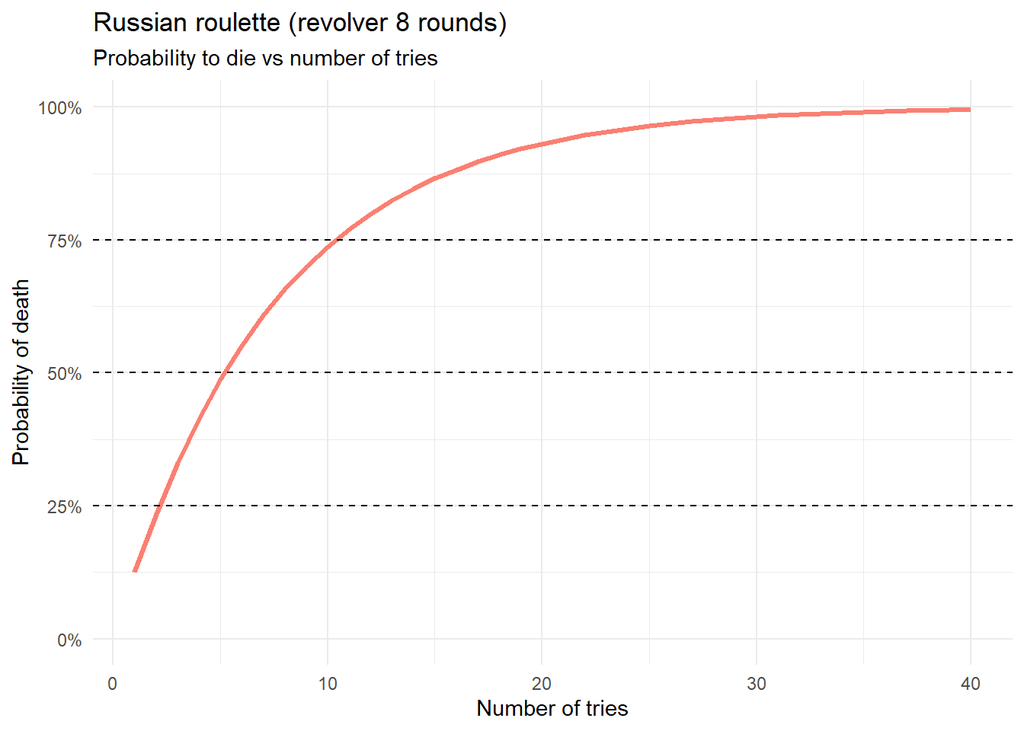

Figure 6: Probability to die in Russian roulette (with a Smith & Wesson) relative to the number of attempts

Table 2: Multiple testing, types of errors.

| Your decision/Reality | **$H_0$ is true** | **$H_0$ is false** | **Total** |
| --- | --- | --- | --- |
| **Do not reject $H_0$** (test non-significant) | $U$ | $T$ | $m -R$ |
| **Reject $H_0$** (test significant) | $V$ | $S$ | $R$ |
| **Total** | $m_0$ | $m - m_0$ | $m$ |

**$m$** total number of tests ; **$m_0$** number of true $H_0$ ; **$m - m_0$** number of false $H_0$ ; **$V$** number of false positives (type-I error) ; **$T$** number of false negative (type-II error) ; **$S$** number of true positive ; **$U$** number of true negative ; **$R$** number of rejections

## 2.2 Family-Wise Error Rate (FWER)

Probability to get **at least** one false positive, knowing the true null hypotheses

**FWER = P(at least one false positive)** ou **$P(V>0 | m_0)$**

We want to stricly control number the number of false positives. Apply we **$m$** is pretty small.

### 2.2.1 Bonferroni method

Stricly control FWER. How it works ? Divide **$\alpha$** by number of test **$m$**.

**reject hypothesis if *p-value* $< \alpha / m$**

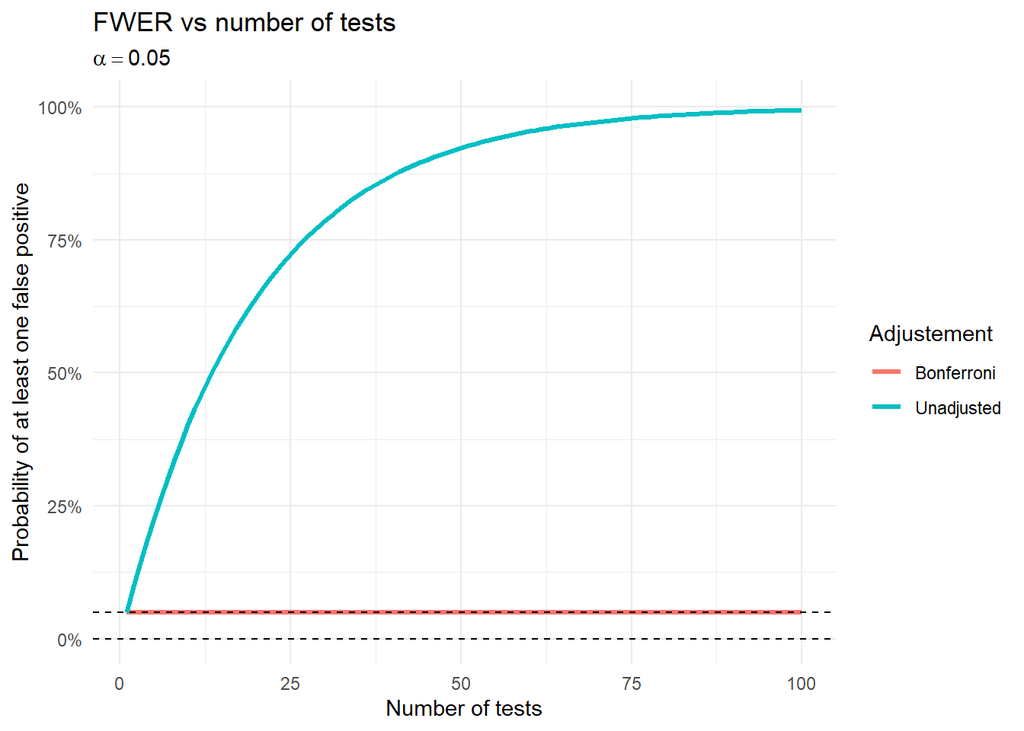

Figure 7: FWER versus number of tests.

**Exercise** : Reproduce figure 7, $m = 100$, $\alpha = 0.05$.

### 2.2.2 Holm method

Method less conservative than Bonferonni, the main idea is make the significance threshold less strict as the p-values get larger

adjusted p-values : $q_{(i)} = \min(1, \max_{j \le i}[(m + 1 - j) * p_{(j)} ])$

Procedure:

1. Sort the p-values in ascending order
2. Compare the smallest p-value to $\alpha / m$
3. If the associated $H_0$ is not rejected **stop**, otherwise **continue**
4. Compare the second smallest p-value to $\alpha / m-1$
5. If the associated $H_0$ is not rejected **stop**, otherwise **continue**
6. Keep going till compare the largent p-value to $\alpha$

## 2.3 False Discovery Rate (FDR)

FDR is the expected number of significant results which are false positive on average.

**$FDR = E(V/R)$** with **$V$** number of false positives (type-I error) ; **$R$** number of rejections **$V/R$** is called false discovery proportion (FDP)

We use the FDR when **$m$** is very large and the FWER is too conservative in this case.

We also need to control the FDR because the FDP increase if there is **a lot of true negatives** in comparison to **true positives**

Example with a test with **$\alpha = 0.05$** and **$\beta$ = 1**: I test 25 variables, 5 of which are true positives So we have 5 true positives and $20*0.05$ **(1)** false positive $FDP = 1/(5+1)$ **$= 16.67\%$**

Same test but with **505 variables** and still 5 true positives So we have 5 true positives and $500*0.05$ **(25**) false positives $FDP = 25/(5+25)$ **$= 83.33\%$**

### 2.3.1 Benjamini-Hochberg method (B-H)

This method control the FDR and the main idea is similar to Holm’s correction Note that B-H **requires independent assumptions or at least positively correlated** between tests to garantee FDR control

adjusted p-values : $q_{(i)} = \min(1, \min_{j \ge i}[(m / j) * p_{(j)} ])$

Procedure with $\alpha$ the desired FDR level:

1. Sort the p-values in ascending order
2. Compare the smallest p-value to $\alpha / m$
3. If the associated $H_0$ is not rejected **stop**, otherwise **continue**
4. Compare the second smallest p-value to $2\alpha / m$
5. If the associated $H_0$ is not rejected **stop**, otherwise **continue**
6. …
7. Keep rejecting $H_0$ until the first $p_{(i)} \ge \frac{i*\alpha}{m}$
8. Do not reject the remaining hypotheses

### 2.3.2 Benjamini-Yekutieli method (B-Y)

B-Y is more **conservative** than B-H requires **no assumptions** on the test dependence structure.

adjusted p-values : $q_{(i)} = \min(1, \min_{j \ge i}[\frac{m*\sum_{k=1}^{m} \frac{1}{k}}{j} * p_{(j)} ])$

Similar procedure as B-H method except that the number of tests is inflated to account for possible dependencies

1. Sort the p-values in ascending order
2. Compare the smallest p-value to $\alpha / (m * \sum_{k=1}^{m} \frac{1}{k})$
3. Compare the second smallest p-value to $2\alpha / (m * \sum_{k=1}^{m} \frac{1}{k})$
4. …
5. Keep rejecting $H_0$ until the first $p_{(i)} \ge \frac{i*\alpha}{(m * \sum_{k=1}^{m} \frac{1}{k})}$
6. Do not reject the remaining hypotheses

### 2.3.3 Methods comparison

```r
#library("DESeq2")
#library("airway")
data("airway")
aw   = DESeqDataSet(se = airway, design = ~ cell + dex)
aw   = DESeq(aw)
awde = as.data.frame(results(aw)) |> dplyr::filter(!is.na(pvalue))

# Because lot of genes select a subset of p-values
# And to facilitate visualization, remove too small p-values e.g 1e-15
set.seed(8765)
awde <- awde[sample(dim(awde)[1], size = 13000),]
awde <- awde[-which(awde$pvalue < 1e-15),]
```

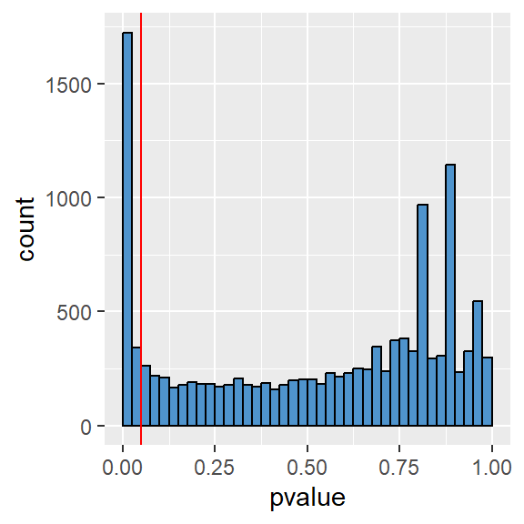

Figure 8 : Histogramm of the raw p-values of airway’s subset data

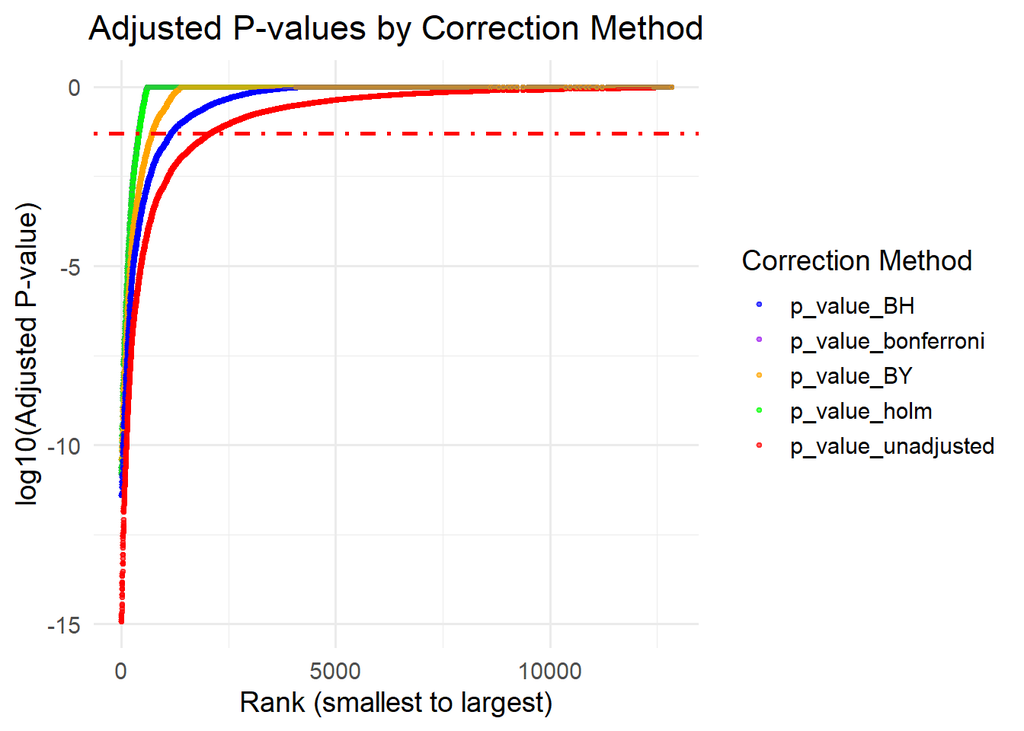

Figure 9: Plot to visualize p-values against rank, colored by methods

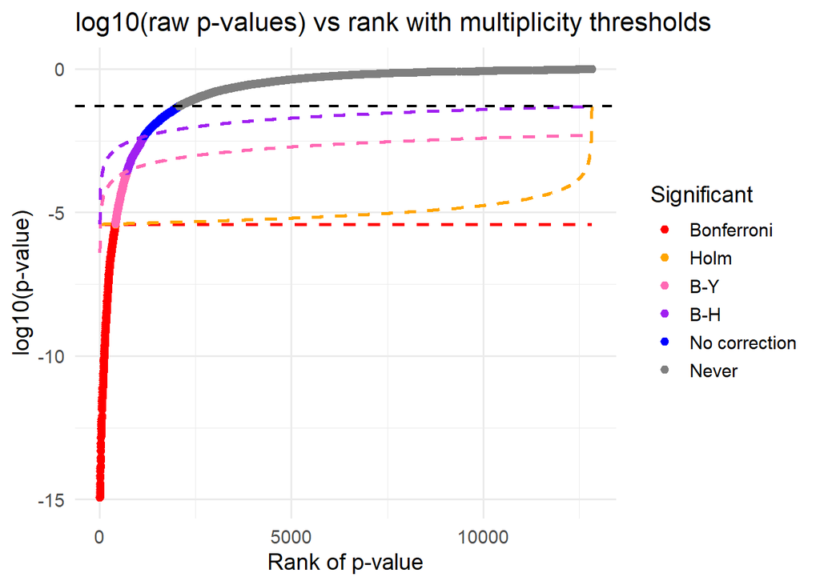

Figure 10: Plot to visualize p-values against rank, colored by method’s decision

**Exercise**: Using the code at the beginning of the section, try to reproduce figure 9.

# 3 Relationship between power, sample size, effect size, and alpha

**Coming Soon**

# 4 Conclusion

- Defining the hypotheses to be tested is crucial
- The t-test is a parametric test comparing means requiring validation conditions and is affected by large sample size
- The Wilcoxon test is an interesting nonparametric alternative to the t-test
- Fisher’s exact test allows two proportions to be compared
- Multiple testing **must** be take into account and your p-values adjusted
- As the proportion of true negatives in the data increases, the **FDR explodes**
- Choose the right correction method according to your objectives